# DM Group Assignment: Thera Bank - Loan Purchase Modelling

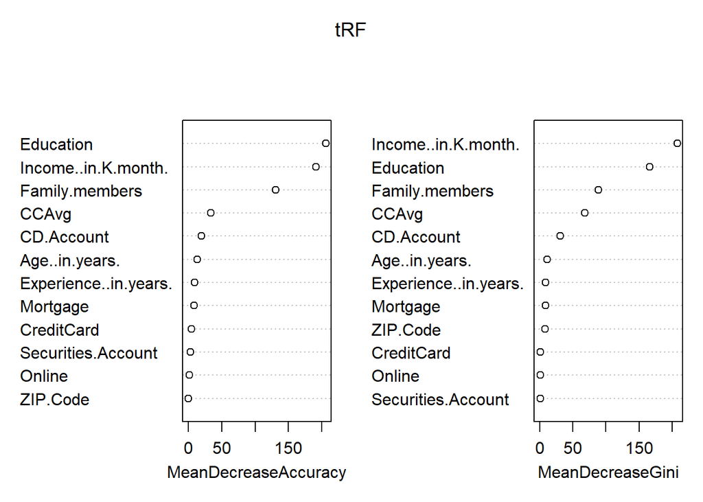

```r
#A plot for the mean decrease in accuracy levels
varImpPlot(tRF)
```

Predicting the Probabilities and the prediction class for the development data

```r
Loanrandom.train$predict.class <- predict(tRF, Loanrandom.train, type="class")
Loanrandom.train$predict.score <- predict(tRF, Loanrandom.train, type="prob")
head(Loanrandom.train)
```

```
##        ID Age..in.years. Experience..in.years. Income..in.K.month.
## 2463 2463             52                    28                  23
## 2511 2511             62                    38                  52
## 2227 2227             25                     1                  98
## 526   526             64                    38                  79
## 4291 4291             66                    42                  95
## 2986 2986             48                    23                  63
##      ZIP.Code Family.members CCAvg Education Mortgage Personal.Loan
## 2463    95828              3   0.4         1        0             0
## 2511    95616              4   1.3         2        0             0
## 2227    90717              1   5.4         1        0             0
## 526     94024              2   2.8         1      179             0
## 4291    94596              2   0.0         3        0             0
## 2986    94606              4   3.6         3        0             0
##      Securities.Account CD.Account Online CreditCard predict.class
## 2463                  0          0      1          0             0
## 2511                  0          0      1          1             0
## 2227                  0          0      1          0             0
## 526                   0          0      0          0             0
## 4291                  0          0      1          0             0
## 2986                  0          0      0          0             0
##      predict.score.0 predict.score.1
## 2463           1.000           0.000
## 2511           1.000           0.000
## 2227           0.830           0.170
## 526            1.000           0.000
## 4291           0.996           0.004
## 2986           0.994           0.006
```

```r
class(Loanrandom.train$predict.score)
```

```
## [1] "matrix" "votes"
```

```r
library(MLmetrics)
MLmetrics::AUC(Loanrandom.train$predict.score[,2], Loanrandom.train$Personal.Loan)
```

```
## [1] 0.9998087
```

Predict for Test data

```r
## Predicting the Probabilities and the prediction class for the Holdout data.
##Would like to see how well the model is able to predict for the holdout data
Loanrandom.test$predict.class <- predict(tRF, Loanrandom.test, type="class")
Loanrandom.test$predict.score <- predict(tRF, Loanrandom.test, type="prob")
head(Loanrandom.test)
```

```
##    ID Age..in.years. Experience..in.years. Income..in.K.month. ZIP.Code
## 4   4             35                     9                 100    94112
## 6   6             37                    13                  29    92121
## 8   8             50                    24                  22    93943
## 9   9             35                    10                  81    90089
## 23 23             29                     5                  62    90277
## 24 24             44                    18                  43    91320
##    Family.members CCAvg Education Mortgage Personal.Loan
## 4               1   2.7         2        0             0
## 6               4   0.4         2      155             0
## 8               1   0.3         3        0             0
## 9               3   0.6         2      104             0
## 23              1   1.2         1      260             0
## 24              2   0.7         1      163             0
##    Securities.Account CD.Account Online CreditCard predict.class
## 4                   0          0      0          0             0
## 6                   0          0      1          0             0
## 8                   0          0      0          1             0
## 9                   0          0      1          0             0
## 23                  0          0      1          0             0
## 24                  1          0      0          0             0
##    predict.score.0 predict.score.1
## 4             0.97            0.03
## 6             1.00            0.00
## 8             1.00            0.00
## 9             1.00            0.00
## 23            1.00            0.00
## 24            1.00            0.00
```

```r
MLmetrics::AUC(Loanrandom.test$predict.score[,2],
               Loanrandom.test$Personal.Loan)
```

```
## [1] 0.9964236
```

RF Model Performance metrics Gini computation

```r
library(ineq)
rfgini = ineq(Loanrandom.test$predict.score[,2], type="Gini")
rfgini
```

```
## [1] 0.8914906
```

gini 0.8914906

AUC computation

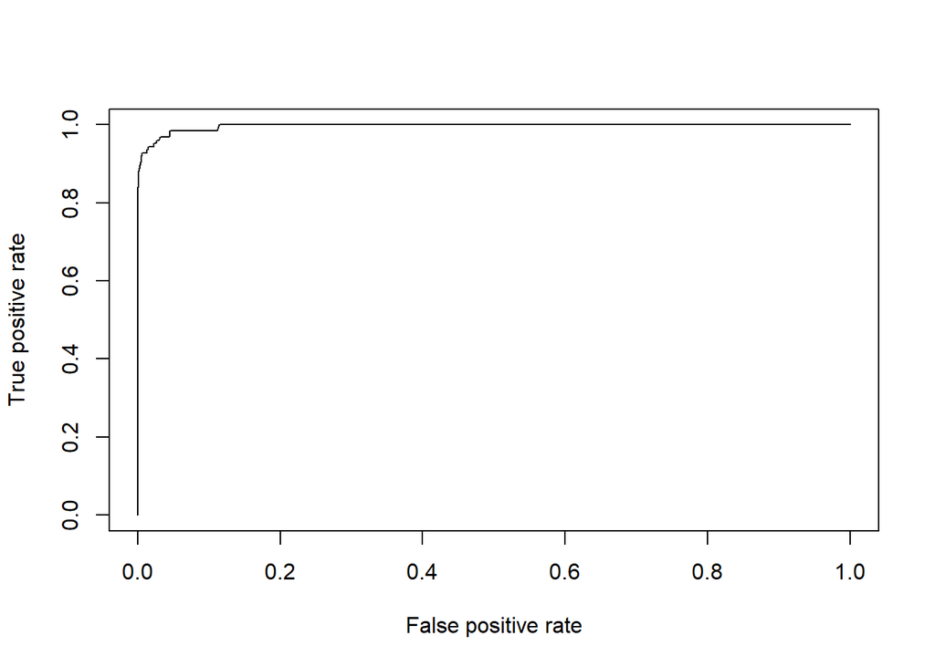

```r
library(ROCR)
pred = prediction(Loanrandom.test$predict.score[,2], Loanrandom.test$Personal.Loan)
perf = performance(pred, "tpr", "fpr")
plot(perf)
```

```r
rfKS = max(attr(perf, 'y.values')[[1]]-attr(perf, 'x.values')[[1]])
rfauc = performance(pred, 'auc');
rfauc = as.numeric(rfauc@y.values)
rfauc
```

```
## [1] 0.9964236
```

```r
rfKS
```

```
## [1] 0.9387533
```

observation auc 0.9964236 KS 0.9387533

print Model performance statistics

```r
with(Loanrandom.test, table(Loanrandom.test$Personal.Loan, Loanrandom.test$predict.class))
```

```
##
##        0    1
##   0 1118    6
##   1   11  115
```

```r
rfauc
```

```
## [1] 0.9964236
```

```r
rfKS
```

```
## [1] 0.9387533
```

```r
rfgini
```

```
## [1] 0.8914906
```

Random Forest Model Performance Metrics

Confusion Matrix

```
  0    1
```

0 1118 6 1 11 115

Above shows RF model predicted majority right with an exception of 17 observation where prediction was wrong

Above captures the confusion matrix results. Model predicted 1118 Negatives as Negatives and 6 wrong Negatives Model predicted 115 Positives as Positives and 11 wrong positives

Sensitivity = True Positive/Total positive = 115/126 = 91.26% specificity - True Negatives/Total Negatives = 1118/1124 = 99.46% Accuracy = True Positives + True Negatives/Total observations = 1118+115/1250 = 98.64%

Model predicted 98.64% observations correctly. Model was able to predict large Negatives correctly as observations in Train dataset as larger Negative values i.e. 0

auc - 0.9964236 KS - 0.9387533 gini- 0.8914906

Again over RF model is better then CART given that it predicted less wrongs. Now let’s try Random Forest with Cross Validation Technique and see if there is any further improvements we could suggest.

## Random Forest Cross-Validation Model using Caret Package

We will use Loancv.train and Loancv.test datsets created in CART step. Would like the model to use same data used in CART and plain RF model.

```r
library(caret)
```

```r
library(lattice)
library(ggplot2)
#The caret package requires its target variables to be a factor. So converting targets to Y/N
Loancv.train$Target_YN = ifelse(Loancv.train$Personal.Loan == 1, "Y", "N")
control <- trainControl(method="cv", number=10,
                        classProbs = TRUE,
                        summaryFunction = twoClassSummary)
set.seed(1212)
rf_fit <- train(Target_YN ~ .,
                data=Loancv.train[,-c(1, 10)],
                method="rf", metric="ROC",
                tuneGrid=expand.grid(.mtry=4),
                ntrees = 101,
                nodesize = 10,
                trControl=control)

#Do look at the ROC result and see the if it is close to results of the train data as well.
print(rf_fit)
```

```
## Random Forest
##
## 3750 samples
##   12 predictor
##    2 classes: 'N', 'Y'
##
## No pre-processing
## Resampling: Cross-Validated (10 fold)
## Summary of sample sizes: 3375, 3375, 3375, 3375, 3375, 3374, ...
## Resampling results:
##
##   ROC       Sens       Spec
##   0.996732  0.9964663  0.8815079
##
## Tuning parameter 'mtry' was held constant at a value of 4
```

Observation ROC Sens Spec  
0.996732 0.9964663 0.8815079

Testing Model Performance on Test dataset

```r
Loancv.test$predict.class <- predict.train(rf_fit,
                                            newdata = Loancv.test,
                                            type="raw")
Loancv.test$predict.score <- predict.train(rf_fit,
                                            newdata = Loancv.test,
                                            type="prob")

#Compare the ROC / AUC value for the Test data set and see if they are close.
#This means the model is no longer overfitted and has some credibility for prediction.
MLmetrics::AUC(Loancv.test$predict.score[,2],
               Loancv.test$Personal.Loan)
```

```
## [1] 0.9963107
```

Observation AUC 0.9963107

Gini computation

```r
library(ineq)
rfcvgini = ineq(Loancv.test$predict.score[,2], type="Gini")
rfcvgini
```

```
## [1] 0.8821768
```

gini 0.8821768

AUC and KS computation

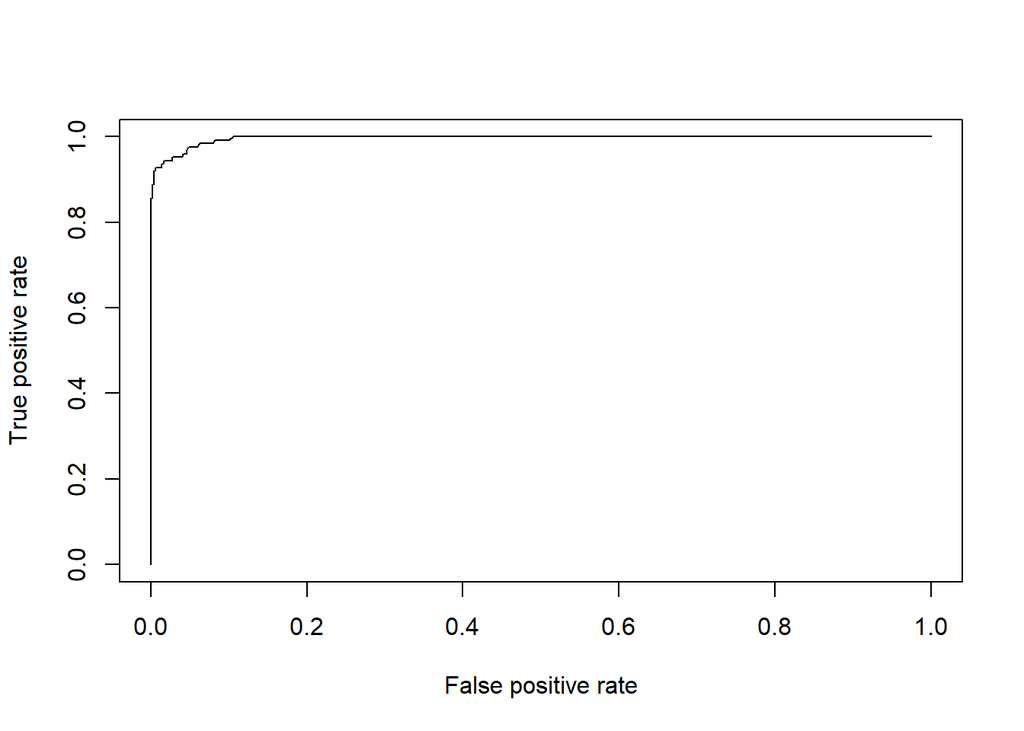

```r
library(ROCR)
pred = prediction(Loancv.test$predict.score[,2], Loancv.test$Personal.Loan)
perf = performance(pred, "tpr", "fpr")
plot(perf)
```

```r
rfcvKS = max(attr(perf, 'y.values')[[1]]-attr(perf, 'x.values')[[1]])
rfcvauc = performance(pred, 'auc');
rfcvauc = as.numeric(rfcvauc@y.values)
rfcvauc
```

```
## [1] 0.9963107
```

```r
rfcvKS
```

```
## [1] 0.9281478
```

observation auc 0.9963107 KS 0.9281478

print Model performance statistics

```r
with(Loancv.test, table(Loancv.test$Personal.Loan, Loancv.test$predict.class))
```

```
##
##        N    Y
##   0 1120    4
##   1   13  113
```

```r
rfcvauc
```

```
## [1] 0.9963107
```

```r
rfcvKS
```

```
## [1] 0.9281478
```

```r
rfcvgini
```

```
## [1] 0.8821768
```

Random Forest Cross Validation Model performance Metrics

Confusion Matrix

```
  N    Y
```

0 1120 4 1 13 113

Overall Model was able to predict large population with an exception of 17 observations where the prediction went wrong.

Sensitivity = True Positive/Total positive = 113/126 = 89.68% specificity - True Negatives/Total Negatives = 1120/1124 = 99.64% Accuracy = True Positives + True Negatives/Total observations = 1120+113/1250 = 98.64%

Model predicted 98% observations correctly. Model was able to predict large Negatives correctly as observations in Train dataset as larger Negative values i.e. 0

auc - 0.9963107 KS - 0.9281478 gini -0.8821768